# Lab4_CatieKitrinos

#load tidyverse

```r
library(tidyverse)
```

#uploaddataset

```r
report_03_11_2020 <-   read_csv(url("https://raw.githubusercontent.com/CSSEGISandData/COVID-19/master/csse_covid_19_data/csse_covid_19_daily_reports/03-11-2020.csv")) %>%
  rename(Country_Region = "Country/Region", Province_State = "Province/State")
```

#checkstructure

```r
str(report_03_11_2020)
```

```
## tibble [216 × 8] (S3: spec_tbl_df/tbl_df/tbl/data.frame)
##  $ Province_State: chr [1:216] "Hubei" NA NA NA ...
##  $ Country_Region: chr [1:216] "China" "Italy" "Iran" "Korea, South" ...
##  $ Last Update   : POSIXct[1:216], format: "2020-03-11 10:53:02" "2020-03-11 21:33:02" ...
##  $ Confirmed     : num [1:216] 67773 12462 9000 7755 2281 ...
##  $ Deaths        : num [1:216] 3046 827 354 60 48 ...
##  $ Recovered     : num [1:216] 49134 1045 2959 288 12 ...
##  $ Latitude      : num [1:216] 31 43 32 36 46.2 ...
##  $ Longitude     : num [1:216] 112.27 12 53 128 2.21 ...
##  - attr(*, "spec")=
##   .. cols(
##   ..   `Province/State` = col_character(),
##   ..   `Country/Region` = col_character(),
##   ..   `Last Update` = col_datetime(format = ""),
##   ..   Confirmed = col_double(),
##   ..   Deaths = col_double(),
##   ..   Recovered = col_double(),
##   ..   Latitude = col_double(),
##   ..   Longitude = col_double()
##   .. )
```

#Viewdata

#installdt

```r
library(DT)
datatable(report_03_11_2020)
```

|  | Province_State | Country_Region | Last Update | Confirmed | Deaths | Recovered | Latitude | Longitude |
| --- | --- | --- | --- | --- | --- | --- | --- | --- |
| 1 | Hubei | China | 2020-03-11T10:53:02Z | 67773 | 3046 | 49134 | 30.9756 | 112.2707 |
| 2 |  | Italy | 2020-03-11T21:33:02Z | 12462 | 827 | 1045 | 43 | 12 |
| 3 |  | Iran | 2020-03-11T18:52:03Z | 9000 | 354 | 2959 | 32 | 53 |
| 4 |  | Korea, South | 2020-03-11T21:13:18Z | 7755 | 60 | 288 | 36 | 128 |
| 5 | France | France | 2020-03-11T22:53:03Z | 2281 | 48 | 12 | 46.2276 | 2.2137 |
| 6 |  | Spain | 2020-03-11T20:53:02Z | 2277 | 54 | 183 | 40 | -4 |
| 7 |  | Germany | 2020-03-11T19:13:17Z | 1908 | 3 | 25 | 51 | 9 |
| 8 | Guangdong | China | 2020-03-11T10:13:06Z | 1356 | 8 | 1282 | 23.3417 | 113.4244 |
| 9 | Henan | China | 2020-03-11T08:13:09Z | 1273 | 22 | 1249 | 33.882 | 113.614 |
| 10 | Zhejiang | China | 2020-03-11T09:33:12Z | 1215 | 1 | 1195 | 29.1832 | 120.0934 |

[output cut: 206 more lines]

## Exercise: 1

## Part 1: The format of the daily reports has changed over time. What are the differences between 3/13/2020, the Friday before spring break 2020 and yesterday 6 months later on 9/13/2020? Load the files into R and use str() and View() (or in the top right corner click on Environment and then the data frame.). Note the in the more recent dates they have changed the column headers so that it is no longer necessary to rename Province_State and Country_Region.

# Upload 3/13 File

```r
report_03_13_2020 <-   read_csv(url("https://raw.githubusercontent.com/CSSEGISandData/COVID-19/master/csse_covid_19_data/csse_covid_19_daily_reports/03-13-2020.csv")) %>%
  rename(Country_Region = "Country/Region", Province_State = "Province/State")
```

#View 3/13

#See strcuture 3/13

```r
str(report_03_13_2020, stringsAsFactors = TRUE)
```

```
## tibble [230 × 8] (S3: spec_tbl_df/tbl_df/tbl/data.frame)
##  $ Province_State: chr [1:230] "Hubei" "Guangdong" "Henan" "Zhejiang" ...
##  $ Country_Region: chr [1:230] "China" "China" "China" "China" ...
##  $ Last Update   : POSIXct[1:230], format: "2020-03-13 11:09:03" "2020-03-13 11:09:03" ...
##  $ Confirmed     : num [1:230] 67786 1356 1273 1215 1018 ...
##  $ Deaths        : num [1:230] 3062 8 22 1 4 ...
##  $ Recovered     : num [1:230] 51553 1296 1249 1197 1005 ...
##  $ Latitude      : num [1:230] 31 23.3 33.9 29.2 27.6 ...
##  $ Longitude     : num [1:230] 112 113 114 120 112 ...
##  - attr(*, "spec")=
##   .. cols(
##   ..   `Province/State` = col_character(),
##   ..   `Country/Region` = col_character(),
##   ..   `Last Update` = col_datetime(format = ""),
##   ..   Confirmed = col_double(),
##   ..   Deaths = col_double(),
##   ..   Recovered = col_double(),
##   ..   Latitude = col_double(),
##   ..   Longitude = col_double()
##   .. )
```

#Count Countries

```r
unique(report_03_13_2020$Country_Region)
```

```
##   [1] "China"                  "Panama"                 "Australia"
##   [4] "Croatia"                "Burkina Faso"           "Albania"
##   [7] "Canada"                 "United Kingdom"         "Philippines"
##  [10] "Nepal"                  "Sri Lanka"              "United Arab Emirates"
##  [13] "Thailand"               "Cambodia"               "San Marino"
##  [16] "Germany"                "Congo (Kinshasa)"       "Honduras"
##  [19] "US"                     "Algeria"                "Reunion"
##  [22] "Oman"                   "Cruise Ship"            "Italy"
##  [25] "Iraq"                   "Lebanon"                "Ukraine"
##  [28] "Austria"                "Switzerland"            "Ireland"
##  [31] "Georgia"                "Bangladesh"             "Kuwait"
##  [34] "North Macedonia"        "Brazil"                 "Greece"
##  [37] "Sweden"                 "Pakistan"               "Norway"
##  [40] "France"                 "Turkey"                 "Bahrain"
##  [43] "Iceland"                "Ecuador"                "Estonia"
```

[output cut: 27 more lines]

#Upload 9/13 File

```r
report_09_13_2020 <-   read_csv(url("https://raw.githubusercontent.com/CSSEGISandData/COVID-19/master/csse_covid_19_data/csse_covid_19_daily_reports/09-13-2020.csv"))
```

#View 9/13 File

#see structure of 9/13

```r
str(report_09_13_2020, stringsAsFactors = TRUE)
```

```
## tibble [3,954 × 14] (S3: spec_tbl_df/tbl_df/tbl/data.frame)
##  $ FIPS               : num [1:3954] NA NA NA NA NA NA NA NA NA NA ...
##  $ Admin2             : chr [1:3954] NA NA NA NA ...
##  $ Province_State     : chr [1:3954] NA NA NA NA ...
##  $ Country_Region     : chr [1:3954] "Afghanistan" "Albania" "Algeria" "Andorra" ...
##  $ Last_Update        : POSIXct[1:3954], format: "2020-09-14 04:26:09" "2020-09-14 04:26:09" ...
##  $ Lat                : num [1:3954] 33.9 41.2 28 42.5 -11.2 ...
##  $ Long_              : num [1:3954] 67.71 20.17 1.66 1.52 17.87 ...
##  $ Confirmed          : num [1:3954] 38716 11353 48254 1344 3388 ...
##  $ Deaths             : num [1:3954] 1420 334 1612 53 134 ...
##  $ Recovered          : num [1:3954] 31638 6569 34037 943 1301 ...
##  $ Active             : num [1:3954] 5658 4450 12605 348 1953 ...
##  $ Combined_Key       : chr [1:3954] "Afghanistan" "Albania" "Algeria" "Andorra" ...
##  $ Incidence_Rate     : num [1:3954] 99.5 394.5 110 1739.5 10.3 ...
##  $ Case-Fatality_Ratio: num [1:3954] 3.67 2.94 3.34 3.94 3.96 ...
##  - attr(*, "spec")=
##   .. cols(
##   ..   FIPS = col_double(),
##   ..   Admin2 = col_character(),
##   ..   Province_State = col_character(),
##   ..   Country_Region = col_character(),
##   ..   Last_Update = col_datetime(format = ""),
##   ..   Lat = col_double(),
##   ..   Long_ = col_double(),
##   ..   Confirmed = col_double(),
##   ..   Deaths = col_double(),
##   ..   Recovered = col_double(),
##   ..   Active = col_double(),
##   ..   Combined_Key = col_character(),
##   ..   Incidence_Rate = col_double(),
##   ..   `Case-Fatality_Ratio` = col_double()
##   .. )
```

#Count Countries

```r
unique(report_09_13_2020$Country_Region)
```

```
##   [1] "Afghanistan"                      "Albania"
##   [3] "Algeria"                          "Andorra"
##   [5] "Angola"                           "Antigua and Barbuda"
##   [7] "Argentina"                        "Armenia"
##   [9] "Australia"                        "Austria"
##  [11] "Azerbaijan"                       "Bahamas"
##  [13] "Bahrain"                          "Bangladesh"
##  [15] "Barbados"                         "Belarus"
##  [17] "Belgium"                          "Belize"
##  [19] "Benin"                            "Bhutan"
##  [21] "Bolivia"                          "Bosnia and Herzegovina"
##  [23] "Botswana"                         "Brazil"
##  [25] "Brunei"                           "Bulgaria"
##  [27] "Burkina Faso"                     "Burma"
##  [29] "Burundi"                          "Cabo Verde"
```

[output cut: 79 more lines]

## Part 2: Many countries have multiple entries representing different regions (e.g. counties and states). To get the counts for a country we need to summarise the data. Use group_by() and summarize() to make a data frame (tibble) with total counts for each country.

## Answer Part 2:

```r
 country_counts <- report_09_13_2020 %>%
  group_by(Country_Region) %>%
  summarize(cases = sum(Confirmed))
 country_counts
```

```
## # A tibble: 188 x 2
##    Country_Region       cases
##    <chr>                <dbl>
##  1 Afghanistan          38716
##  2 Albania              11353
##  3 Algeria              48254
##  4 Andorra               1344
##  5 Angola                3388
##  6 Antigua and Barbuda     95
##  7 Argentina           555537
##  8 Armenia              45862
##  9 Australia            26692
## 10 Austria              33159
## # … with 178 more rows
```

## Part 3: To get counts for confirmed cases per U.S state use filter() to select US and group_by and summarize as above.

## Answer Part 3:

```r
 state_count <- report_09_13_2020 %>%
  filter(Country_Region == "US") %>%
  group_by(Province_State) %>%
  summarize(cases = sum(Confirmed))
state_count
```

```
## # A tibble: 58 x 2
##    Province_State        cases
##    <chr>                 <dbl>
##  1 Alabama              138755
##  2 Alaska                 6268
##  3 Arizona              208512
##  4 Arkansas              70219
##  5 California           761728
##  6 Colorado              61293
##  7 Connecticut           54326
##  8 Delaware              18849
##  9 Diamond Princess         49
## 10 District of Columbia  14592
## # … with 48 more rows
```

## Part 4: It will be difficult to make simple graphs with the data from all countries in the world or even the US states. Use arrange_by() and slice() to get just the top 10 countries for Deaths.

## Answer Part 4:

```r
death_counts <- report_09_13_2020 %>%
  group_by(Country_Region) %>%
  summarize(deaths = sum(Deaths)) %>%
  arrange(desc(deaths))
death_counts
```

```
## # A tibble: 188 x 2
##    Country_Region deaths
##    <chr>           <dbl>
##  1 US             194071
##  2 Brazil         131625
##  3 India           78586
##  4 Mexico          70821
##  5 United Kingdom  41717
##  6 Italy           35610
##  7 France          30903
##  8 Peru            30526
##  9 Spain           29747
## 10 Iran            23157
## # … with 178 more rows
```

```r
  top_10_death <- slice(death_counts, 1:10)

  top_10_death
```

```
## # A tibble: 10 x 2
##    Country_Region deaths
##    <chr>           <dbl>
##  1 US             194071
##  2 Brazil         131625
##  3 India           78586
##  4 Mexico          70821
##  5 United Kingdom  41717
##  6 Italy           35610
##  7 France          30903
##  8 Peru            30526
##  9 Spain           29747
## 10 Iran            23157
```

# Exercise : Part 2

# Question 5: Make plots using geom_point() of the 10 countries with the confirmed cases and deaths (two separate graphs) on 3/12/2020 and 9/12/2020.

```r
country_counts1 <- report_03_13_2020 %>%
  group_by(Country_Region) %>%
  summarize(cases = sum(Confirmed)) %>%
  arrange(desc(cases))
  top_10_cases1 <- slice(country_counts1, 1:10)
```

```r
top_10_cases1
```

```
## # A tibble: 10 x 2
##    Country_Region cases
##    <chr>          <dbl>
##  1 China          80945
##  2 Italy          17660
##  3 Iran           11364
##  4 Korea, South    7979
##  5 Spain           5232
##  6 Germany         3675
##  7 France          3667
##  8 US              2179
##  9 Switzerland     1139
## 10 Norway           996
```

# 3/13 Cases

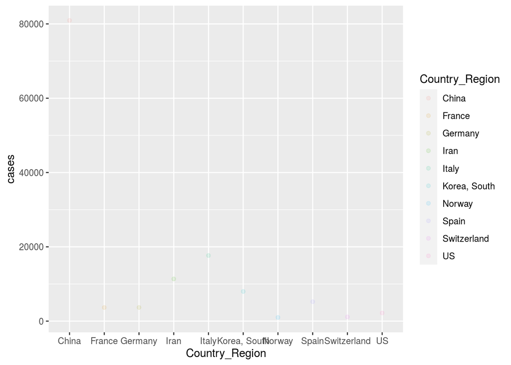

```r
ggplot(data = top_10_cases1, mapping = aes(x = Country_Region, y = cases)) +
    geom_point(alpha = 0.1, aes(color = Country_Region))
```

# 3/13 Deaths

```r
country_counts2 <- report_03_13_2020 %>%
  group_by(Country_Region) %>%
  summarize(deaths = sum(Deaths)) %>%
  arrange(desc(deaths))
  top_10_cases2 <- slice(country_counts2, 1:10)
```

```r
top_10_cases2
```

```
## # A tibble: 10 x 2
##    Country_Region deaths
##    <chr>           <dbl>
##  1 China            3180
##  2 Italy            1266
##  3 Iran              514
##  4 Spain             133
##  5 France             79
##  6 Korea, South       66
##  7 US                 47
##  8 Japan              19
##  9 Switzerland        11
## 10 Netherlands        10
```

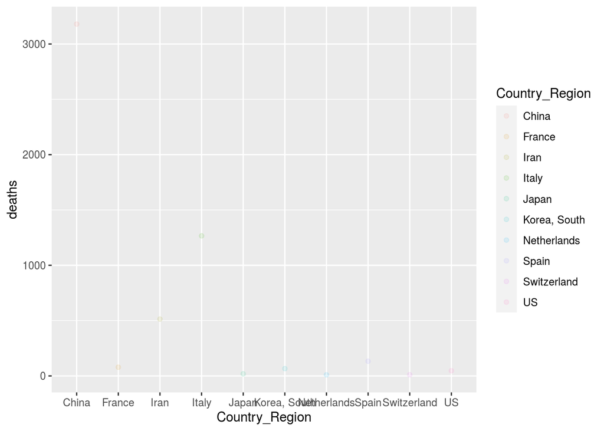

```r
ggplot(data = top_10_cases2, mapping = aes(x = Country_Region, y = deaths)) +
    geom_point(alpha = 0.1, aes(color = Country_Region))
```

# 9/13 Cases

```r
country_counts3 <- report_09_13_2020 %>%
  group_by(Country_Region) %>%
  summarize(cases = sum(Confirmed)) %>%
  arrange(desc(cases))
  top_10_cases3 <- slice(country_counts3, 1:10)
```

```r
  top_10_cases3
```

```
## # A tibble: 10 x 2
##    Country_Region   cases
##    <chr>            <dbl>
##  1 US             6519573
##  2 India          4754356
##  3 Brazil         4330455
##  4 Russia         1059024
##  5 Peru            722832
##  6 Colombia        716319
##  7 Mexico          668381
##  8 South Africa    649793
##  9 Spain           566326
## 10 Argentina       555537
```

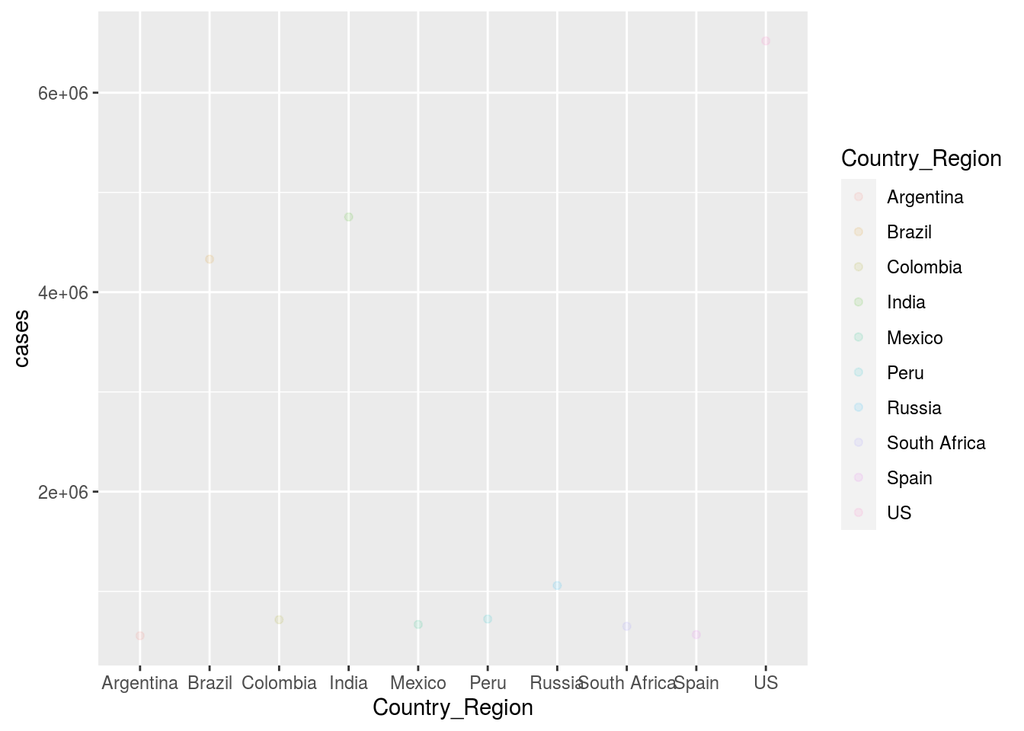

```r
ggplot(data = top_10_cases3, mapping = aes(x = Country_Region, y = cases)) +
    geom_point(alpha = 0.1, aes(color = Country_Region))
```

# 9/13 deaths

```r
country_counts4 <- report_09_13_2020 %>%
  group_by(Country_Region) %>%
  summarize(deaths = sum(Deaths)) %>%
  arrange(desc(deaths))
  top_10_cases4 <- slice(country_counts4, 1:10)
```

```r
top_10_cases4
```

```
## # A tibble: 10 x 2
##    Country_Region deaths
##    <chr>           <dbl>
##  1 US             194071
##  2 Brazil         131625
##  3 India           78586
##  4 Mexico          70821
##  5 United Kingdom  41717
##  6 Italy           35610
##  7 France          30903
##  8 Peru            30526
##  9 Spain           29747
## 10 Iran            23157
```

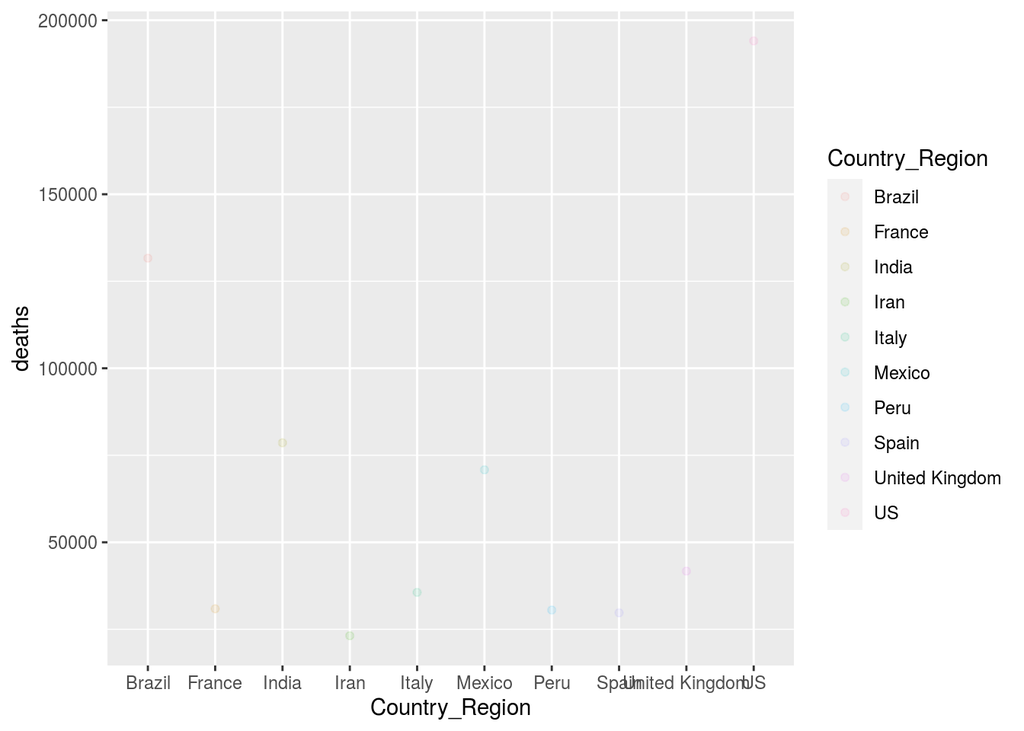

```r
ggplot(data = top_10_cases4, mapping = aes(x = Country_Region, y = deaths)) +
    geom_point(alpha = 0.1, aes(color = Country_Region))
```

# Exercise 6: Make using geom_bar of the 10 states with the most confirmed cases and deaths (two separate graphs) on 3/12/2020 and 9/12/2020.

# 3/13 State case counts

```r
 state_count2 <- report_03_13_2020 %>%
  filter(Country_Region == "US") %>%
  group_by(Province_State) %>%
  summarize(cases = sum(Confirmed))  %>%
  arrange(desc(cases))
state_count2
```

```
## # A tibble: 53 x 2
##    Province_State   cases
##    <chr>            <dbl>
##  1 Washington         568
##  2 New York           421
##  3 California         282
##  4 Massachusetts      123
##  5 Florida             50
##  6 Colorado            49
##  7 Diamond Princess    46
##  8 Illinois            46
##  9 Texas               43
## 10 Georgia             42
## # … with 43 more rows
```

```r
top_10_cases5 <- slice(state_count2, 1:10)

top_10_cases5
```

```
## # A tibble: 10 x 2
##    Province_State   cases
##    <chr>            <dbl>
##  1 Washington         568
##  2 New York           421
##  3 California         282
##  4 Massachusetts      123
##  5 Florida             50
##  6 Colorado            49
##  7 Diamond Princess    46
##  8 Illinois            46
##  9 Texas               43
## 10 Georgia             42
```

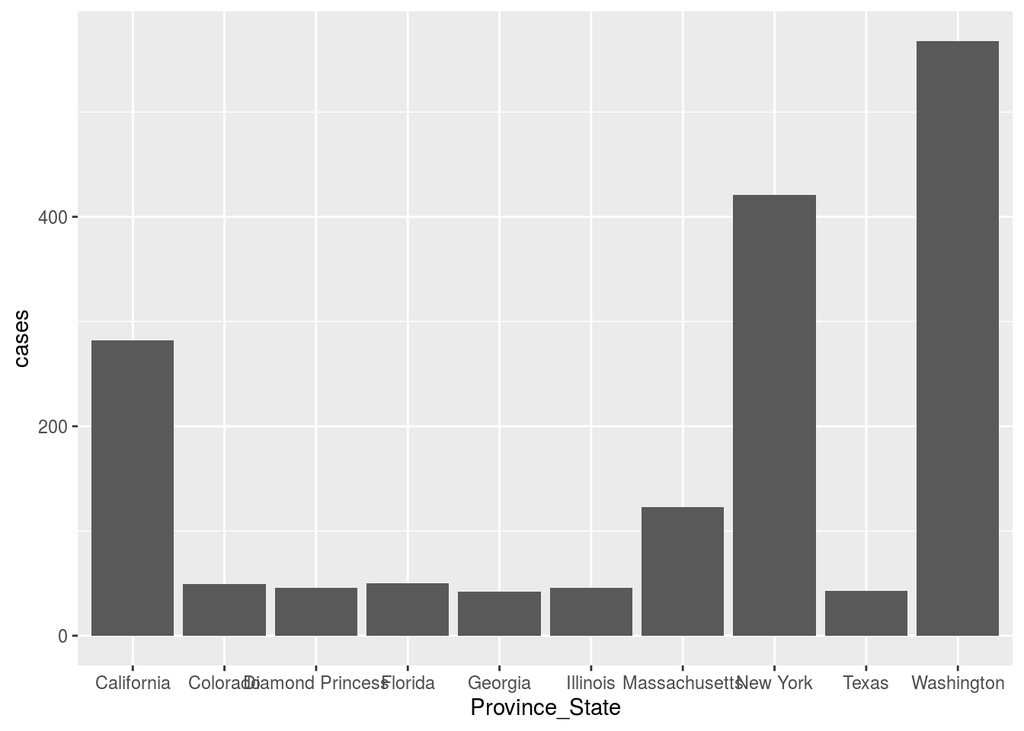

```r
ggplot(data = top_10_cases5, mapping = aes(x = Province_State, y = cases)) +
    geom_bar(stat = 'identity')
```

# 3/13 state death counts

```r
 state_count4 <- report_03_13_2020 %>%
  filter(Country_Region == "US") %>%
  group_by(Province_State) %>%
  summarize(deaths = sum(Deaths))  %>%
  arrange(desc(deaths))
state_count4
```

```
## # A tibble: 53 x 2
##    Province_State deaths
##    <chr>           <dbl>
##  1 Washington         37
##  2 California          4
##  3 Florida             2
##  4 Georgia             1
##  5 Kansas              1
##  6 New Jersey          1
##  7 South Dakota        1
##  8 Alabama             0
##  9 Alaska              0
## 10 Arizona             0
## # … with 43 more rows
```

```r
top_10_cases6 <- slice(state_count4, 1:10)

top_10_cases6
```

```
## # A tibble: 10 x 2
##    Province_State deaths
##    <chr>           <dbl>
##  1 Washington         37
##  2 California          4
##  3 Florida             2
##  4 Georgia             1
##  5 Kansas              1
##  6 New Jersey          1
##  7 South Dakota        1
##  8 Alabama             0
##  9 Alaska              0
## 10 Arizona             0
```

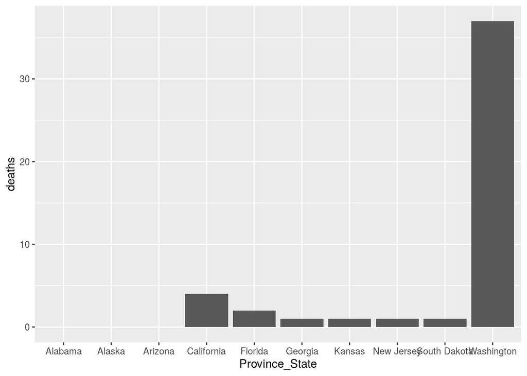

```r
ggplot(data = top_10_cases6, mapping = aes(x = Province_State, y = deaths)) +
    geom_bar(stat = 'identity')
```